# NLP with the Simpsons

Eeva Rasi

11th 2018

## Overview

Natural Language Processing (NLP) is an area of computer science and AI concerned with the interactions between computers and human languages [1]. Tasks in this area may contain for example text summarizing, sentiment analysis and text categorization. During this exercise I will demostrate some NLP and text mining features.

I’m using the Simpsons dataset provided by the Kaggle: https://www.kaggle.com/ambarish/fun-in-text-mining-with-simpsons/data

The dataset contains the characters, locations, episode details, and script lines for approximately 600 Simpsons episodes. I will use only the characters and script lines data.

```r
# needed libraries
library(ggplot2)
library(kableExtra)
library(knitr)
library(tm)
library(SnowballC)
library(wordcloud)
library(stringi)
library(tidytext)
library(dplyr)
```

## Exploratory Data Analysis

### Getting the data

```r
# reading the data
scripts.df = read.csv("./simpsons_script_lines.csv", stringsAsFactors=FALSE)
characters.df = read.csv("./simpsons_characters.csv", stringsAsFactors=FALSE)

# convert character_id as integer to enable join function
scripts.df$character_id = as.integer(scripts.df$character_id)

# joining together scripts & characters, using inner join to find only scripts associated with a character
all.df <- inner_join(scripts.df, characters.df, by = c("character_id" = "id"))
```

## Cleaning and preprocessing

This dataset already contains a normalized text column, but normally when dealing with text we need to do some preprocessing and cleaning like:

1. Make all character in lower case
2. Remove numbers
3. Remove punctuation
4. Remove extra whitespaces
5. Remove Non-ASCII characters
6. Remove stop words
7. Stemming

`tidytext` package contains`unnest_token` function which does the following:

- Splits the text into single words
- Removes all punctuation
- Converts each word to lowercase

For text analysis I create a subset called `simpsons.df` which only contains columns *id, normalized_text*. I also filter empty scripts.

```r
simpsons.df <- all.df %>%
               select(id, normalized_text) %>%
               filter(! normalized_text == "")
```

## Text Analysis

### The most common words

The word cloud below shows the top 50 most frequent words. I have used `anti_join` and `stop_words` to remove stop words as they are not useful for an analysis. Stop words are typically extremely common words such as “the”, “of”, “to”, and so forth in English [2].

[figure not shown]

```r
simpsons.df  %>%
            unnest_tokens(word, normalized_text) %>%
            anti_join(stop_words) %>%
            count(word,sort = TRUE) %>%
            head(50) %>%
            with(wordcloud(word, n, max.words = 50, random.order=FALSE, colors=brewer.pal(6, "Dark2")))
```

### N-Grams

While analysing texts we are not interested only about single words but also relationships between words. For that purpose we can use N-grams are which define how often word A is followed by word B [2].

```r
# create bigrams
bigrams.df <- simpsons.df %>%
              select("normalized_text")  %>%
              unnest_tokens(bigram, normalized_text, token = "ngrams", n = 2)

# create trigrams
trigrams.df <- simpsons.df %>%
              select("normalized_text")  %>%
              unnest_tokens(trigram, normalized_text, token = "ngrams", n = 3)

# count & sort
bigrams.df <- bigrams.df %>%
              count(bigram, sort = TRUE)

trigrams.df <- trigrams.df %>%
               count(trigram, sort = TRUE)
```

Top 20 bigrams and trigrams.

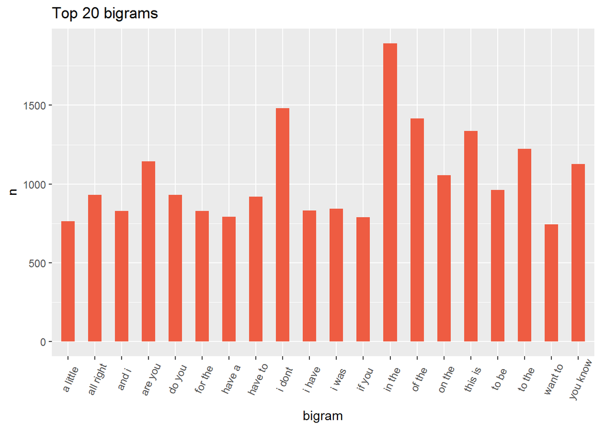

```r
# create a plot to visualize top 20 bigrams
g <- ggplot(head(bigrams.df,20), aes(x=bigram, y=n))
g + geom_bar(stat="identity", width = 0.5, fill="tomato2") +
      labs(title="Top 20 bigrams") +
      theme(axis.text.x = element_text(angle=65, vjust=0.6))
```

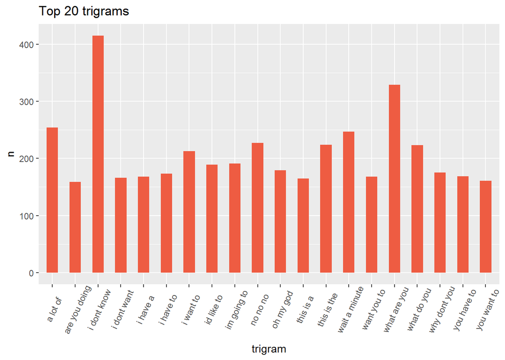

```r
# create a plot to visualize top 20 trigrams
g <- ggplot(head(trigrams.df,20), aes(x=trigram, y=n))
g + geom_bar(stat="identity", width = 0.5, fill="tomato2") +
      labs(title="Top 20 trigrams") +
      theme(axis.text.x = element_text(angle=65, vjust=0.6))
```

### Sentiment analysis

As a human we intuitively understand a text, we use our understanding whether a section of text is positive or negative. But for computers we need to use the tools of text mining to recognise the emotional content of text programmatically [2]. The `tidytext` package contains three sentiment different lexicons in the sentiments dataset:

- AFINN (by Finn Årup Nielsen)
- bing (by Bing Liu and co.)
- nrc (by Saif Mohammad & Peter Turney)

I’m using `afinn` to find out most positive and most negative words.

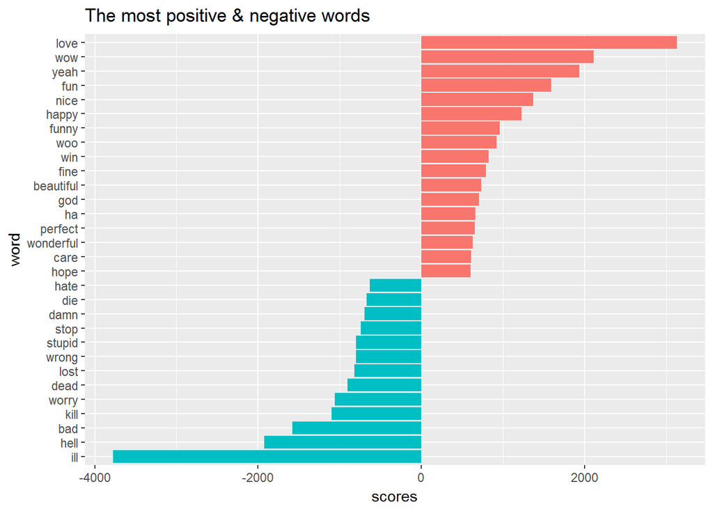

```r
# Count lexicon scores
afinn.scores <- simpsons.df %>%
                unnest_tokens(word, normalized_text) %>%
                anti_join(stop_words) %>%
                inner_join(get_sentiments("afinn"), by = "word") %>%
                group_by(word) %>%
                summarize(occurences = n(), scores = sum(score)) %>%
                arrange(scores)

# Visualize results
afinn.scores %>%
                top_n(30, abs(scores)) %>%
                mutate(word = reorder(word, scores)) %>%
                ggplot(aes(word, scores, fill = scores < 0)) +
                geom_col(show.legend = FALSE) +
                coord_flip() +
                labs(title="The most positive & negative words")
```

### References

[1] Wikipedia, Natural Language Processing definition, https://en.wikipedia.org/wiki/Natural-language_processing

[2] Text Mining with R, Julia Silge & David Robinson, https://www.tidytextmining.com